# MSBMI 33200: Lecture 2

Anoop Mayampurath

October 14, 2019

## Linear Regression Models

Linear Regression Models are used when the outcome is continous.

Given a set of $p$ features $X = (x_1, x_2 \dots x_p)$, we fit to a continous outcome $y$ using:

$$Y = w_{0} + \sum_{j=1}^{p}x_{j}w_j$$

The term $w_{0}$ is the intercept (recall as $\beta_{0}$). It is also called as “bias” in machine learning. A good way to collapse the above formula is to include $w_0$ and $w_j$ into a weight matrix, by adding a column of 1 to the $X$ matrix.

$$y = Xw$$

For fitting a linear model to the training data, we use the ordinary least squares (OLS) approach.

Recall that the OLS solution attempts to find $w$ by trying to minimize the residual sum of squares, i.e.,

$$\text{minimize } RSS = \sum_{i=1}^{n}(y_i - x_{i}^{T}w)^2$$

In matrix form, this is written as:

$$\text{minimize } RSS = (y - Xw)^T(y-Xw)$$

This has a unique solution if $X^{T}X$ is non-singular.

$$\hat{w} = (X^{T}X)^{-1}X^{T}y$$

This is called as the Normal Equation.

However, finding the inverse of a large dimensional matrix is very computationally intensive. Thus, finding $\hat{w}$ for a dataset with a large of predictors is sometimes intractable.

## Loss function (or Cost Function)

$$J(w) = \frac{1}{2n}\sum_{i=1}^{n}(y_i - x_{i}^{T}w)^2$$
For different values of $w$, we get different $J{w}$. Thus, we can define “learning” as finding for all values of $w$, the lowest value of $J(w)$

$$\underset{w}{\textit{minimize }} J(w)$$

A plot of the loss function $J{w}$ for different $w$ is called as a contour plot.

- For a model with 1 parameter, i.e. a single element $w$, we get a polynomial curve
- For a model with 2 parameters, i.e., a $w$ with 2 elements, we will get a surface plot

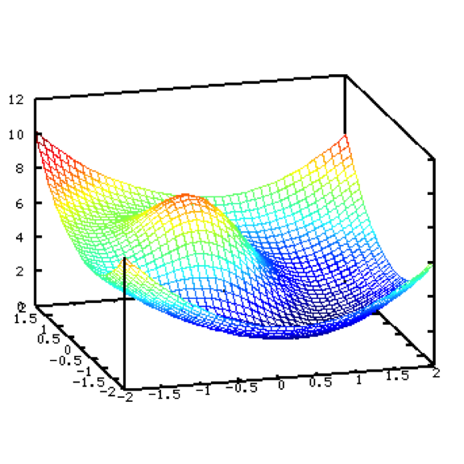

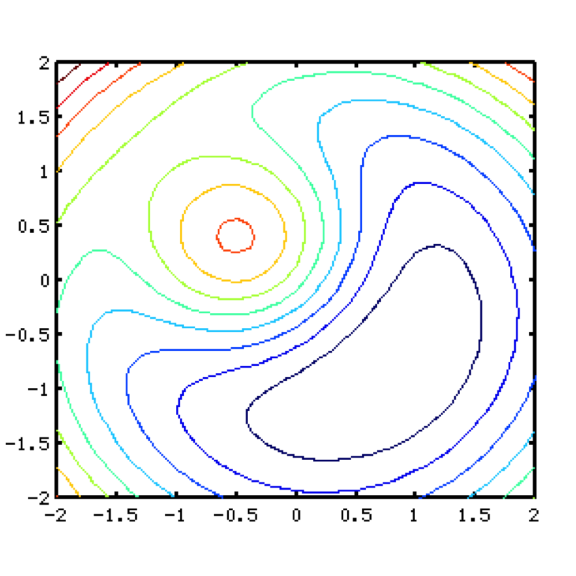

- Each ellipse is colored based on value of $J(w)$
- Parameters far from the center are a poor fit.
- Finding the miminum is done using an algorithm called Gradient Descent

## Gradient Descent

The simplest approach to finding the minimum $J(w)$ is to choose a direction that minimizes $J(w)$ and keep following it. This is called as following the negative gradient. The algorithm is as follows:

- 1. Initialize $w$ with random values.
- 2. Calculate $J(w)$.
- 3. Choose the gradient that reduces $J(w)$ the most.
- 4. Update $w$ with:

$$w^{new} = w^{old} - \eta \frac{\partial J(w^{old})}{\partial w^{old}}$$

- 5. Repeat 2-4 until $w^{new} - w^{old} < \epsilon$ (called as convergence)
- The parameter $\eta > 0$ is called the learning parameter. We have to be careful about setting this. Too high $\eta$ will cause us to miss the global minima, while too low $\eta$ will cause us never to reach the global minima.
- The parameter $\epsilon$ is called as the tolerance.
- Gradient Descent is dependent on the initial values of $w$. Thus, you will have to run this a couple of times to ensure convergence
- For this to work, $J(w)$ has to be a convex as well as a continous function.
- Typically, the gradient vector $\frac{\partial J(w^{old})}{\partial w^{old}}$ is calculated by taking the partials across each of the $p$ predictors. However, this is still computationally complex for large datasets.

## Stochastic Gradient Descent (SGD)

- This is a variant of the gradient descent that simply calculates the gradient at each update step for a single arbitarily chosen data point.
- This is faster, however the path to the global minima will be extremely jumpy. Additionally, the algorithm is liekly to bounce around closer to the global minima. This is alleviated by using a decaying learning rate that starts off with large values but decays with very weight update step.
- SGD does not gurantee reaching the optimal value, but in practice this has shown to do very well in getting close. Further, it is less likely to get stuck in a local minima.
- SGD and GD both converge faster if the features are normalized. The classic standard is to mean-normalize to make mean 0 and standard deviation as 1.

## Logistic Regression Models

Logistic Regression is used when the outcome is binary. Consider the equation below for linear regression:

$$Y = Xw$$
Instead of $Y$, logistic regression models $P(Y=1)$ and instead of $Xw$, logistic regression uses $h_{w}(X)$ where $h(z) = \frac {1}{1+e^{-z}}$. Thus, the model equation is

$$P(Y= 1) = \frac {1}{1+e^{-Xw}}$$

The function $h()$ is called as a sigmod function or logit. It takes the following shape.

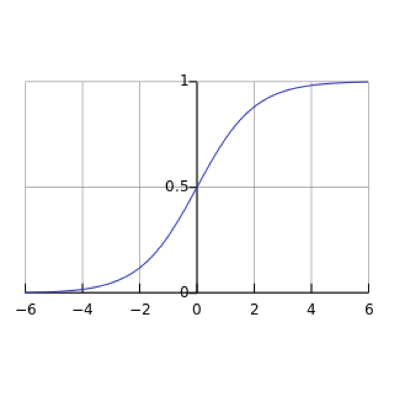

Thus, the loss function for a single data point $i$ becomes

$$J^{i}(w)=
\begin{cases}
- log(\hat{P}(y_i=1)),& \text{if } y_i = 1\\
- log(1 - \hat{P}(y_i=1)),& \text{if } y_i = 0
\end{cases}$$

or

$$J^{i}(w)=
\begin{cases}
- log(\hat{P}),& \text{if } y_i = 1\\
- log(1 - \hat{P}),& \text{if } y_i = 0
\end{cases}$$

The total loss function for all data points $i= 1 \dots n$ is called as log-loss and is written as:

$$J(w) = - \frac{1}{n} \sum_{i=1}^{n}[y_ilog(\hat{P}) + (1-y_i)log(1-\hat{P})]$$
This is again a convex function and thus can be solved using GD and SGD.

## Regularization

- Multicollinearity is a condition when one predictor is highly correlated with another or a combination of predictors.
- Why is this a problem? Collinearity causes the weights of certain predictors to have a very large variance. This is more a problem for explaining the predictors than actual predictions.
- However, when collinearity is present, the weights become unstable with small changes to data. This is classic case of over-fitting. In the event the new test data does not mimic the training data, there will be large errors in predicitons.
- We use regularization to handle collinearity (and to a large extent overfitting as well)

Regularization constraints the weights of all the predictors so as to limit the effect that a single predictor has. You do this by modifying the loss function to include the weights as well. For example, in linear regression models, the cost function becomes:

$$J(w) = \frac{1}{2n}\sum_{i=1}^{n}(y_i - x_{i}^{T}w)^2 + \lambda\sum_{j=1}^{p}w_{j}^{2}$$
Minimizing $J(w)$ will lead to minimization of error as well as “shrinking” all the weight.

The parameter $\lambda$ is called the regularization parameter and is set to balance the need to avoid overfitting and the need to keep predictors in play. If $\lambda$ is very large, all weights become close to 0. If $\lambda$ is too small, then you will overfit. Use cross-validation to choose correctly.

- You can regularize normal equations too by simply adding the constraint.

$$\hat{w} = (X^{T}X + \lambda I^*)^{-1}X^{T}y$$

where $I^*$ is $I$ (the identity matrix) but with the first element as 0, since you typically do no regularize $w_0$

- For the logistic regression, regularization is done by changing the loss function to

$$J(w) = \frac{1}{n} \sum_{i=1}^{n}[y_ilog(\hat{P}) + (1-y_i)log(1-\hat{P})] + \lambda \sum_{j=1}^{p}w_{j}^{2}$$

## In R

## Packages

```r
library(caret)
library(pROC)
```

## Training a linear regression model

```r
fitControl <- trainControl(method = "cv", number = 3)
lm.model <- train(outcome  ~ . , data = training_data, method = "lm",
                  trControl = fitControl)
```

## Training a logistic regression model

```r
fitControl <- trainControl(method = "cv", number = 5)
glm.model <- train(outcome ~ . ,
                   data = training_data,
                   method = "glm",
                   family = "binomial",
                   trControl = fitControl)
```

## Testing a linear regression model

```r
test_data$predicted_outcome <- predict(object = lm.model, test_data)
postResample(pred = test_data$predicted_outcome, obs = test_data$true_outcome)
```

## Testing a logistic regression model

```r
# remember to keep the outcome as a factor
preds <- predict(object = glm.model,
                 test_data, type = "prob")
test_data$predicted_prob_outcome <- preds$Yes
test_data$predicted_prob_outcome <- glm_perf <- roc(response = test_data$true_outcome,
                  predictor = test_data$predicted_prob_outcome)
print(auc(glm_perf))
print(ci.auc(glm_perf))
```

## Regularization

```r
library(glmnetUtils)

## create parameter grids for alpha and lambda
## for ridge regression, alpha is 0
alpha <- c(0)
## lambda start: lambda that corresponds to minimal deviance.
## lambda stop: lambda that has deviance within one standard error.
## both these can be found using cv.glmnet command

objGrid <- expand.grid(alpha = alpha_grid,
                       lambda = lambda_grid)


m_ridge <- glmnet(outcome ~.,
                  data = train_data,
                  family = "binomial",
                  alpha = 0)

fitControl <- trainControl(method = "cv", number= 5)
reg.model <- train(outcome ~ . ,
                   data = training_data,
                   method = "glmnet",
                   tuneGrid = objGrid,
                   trControl = fitControl)
```

## Python

## Linear Regression

```python
from sklearn.linear_model import LinearRegression
import numpy
lm_model = LinearRegression()
lm_model.fit(X_train, y_train)
test_predictions = lm_model.predict(X_test)
R = numpy.corrcoef(test_predictions, Y_test)
R2 = R**2
```

## Logistic Regression

```python
from sklearn.linear_model import LogisticRegression
from sklearn.metrics import roc_auc_score
logreg_model = LogisticRegression()
logreg_model.fit(X_train, y_train)
test_predictions = logreg_model.predict_proba(X_test)
auc = roc_auc_score(y_test, test_predictions)
```

## Regularization

```python
# method 1
from sklearn.linear_model import Ridge
ridge_model = Ridge(alpha = 1, solved = "cholesky")

# method 2
from sklearn.linear_model import RidgeClassifier # method 2
ridge_model = RidgeClassifier(alpha = 1)


ridge_model.fit(X_train, y_train)
test_predictions = logreg_model.predict_proba(X_test)
auc = roc_auc_score(y_test, test_predictions)
```